# Project1 HappyDB analysis

Yu Yao

2/11/2019

# **The differences of happiness between single and married parents**

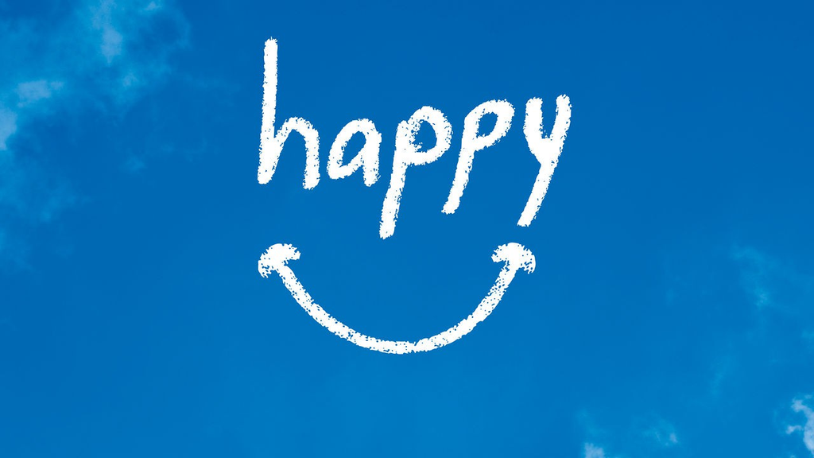

# Background information

According to data published by the United States’ Census Bureau, around 30% of children in the United States are raised by single parents. It has become a social debate.However, instead of considering it from children’s aspect, another interesting question is what are the things that make single parents happy? Are they different from those for married people?

# Data pretreatment

HappyDB is a large scale collection of happy moments on Amazon Mechanical Turk (MTurk) workers. You can read more about it on https://arxiv.org/abs/1801.07746.

The necessary packages used are listed. The original data are imported and we have done some cleaning of the data. We removed punctuations, extra whitespace, empty words and numbers and converted upper case to lower case. We reduced words to their stems and removed meaningless stop words. We further combined the demographic data with the original data set. We then imported the demographic data to our cleaned data. So we will use this cleaned and combined data for our analysis below.

The four democraphics groups in this topic will be divided into: single with children, married with children. We also will have two reference groups: single non-parent and married without children.

```r
library(tidyverse)
library(tidytext)
library(DT)
library(scales)
library(wordcloud2)
library(gridExtra)
library(ngram)
library(tm)
library(wordcloud)
library(topicmodels)
library(ggplot2)
library(dplyr)
library(gplots)
library(reshape2)
library(stringr)
R.Version()$version.string
```

```
[1] "R version 3.5.2 (2018-12-20)"
```

# General Analysis

## Wordcloud for all data

From all the data we have. We can roughly find the key word of happiness formthe worldcloud for all four groups of people.

```r
wordcount <- hm_data$text %>%
  str_trim() %>%
  lapply(strsplit," ") %>%
  unlist() %>%
  table() %>%
  as.data.frame()
colnames(wordcount) <- c("Keyword","Freq")
sorted <- wordcount %>% dplyr::arrange(desc(Freq))
png(filename = ".../output/wordcloud.png")
wordcloud2(sorted[1:100,],color = "random-light",size = 0.5,shape = "circle")
```

[interactive chart not shown]

Words that frequently appeared in MTurk workers’ happy moments descriptions are: **friend**, **day**, **time**, **watched**, **family** and **home** etc. Thus, generally people will feel happy about things or events related to their friends, families, watching shows and so on.

## Length of Sentences

The length of sentences are stored in the count column of our cleaned dataset and we visualized this through a scatterplot.

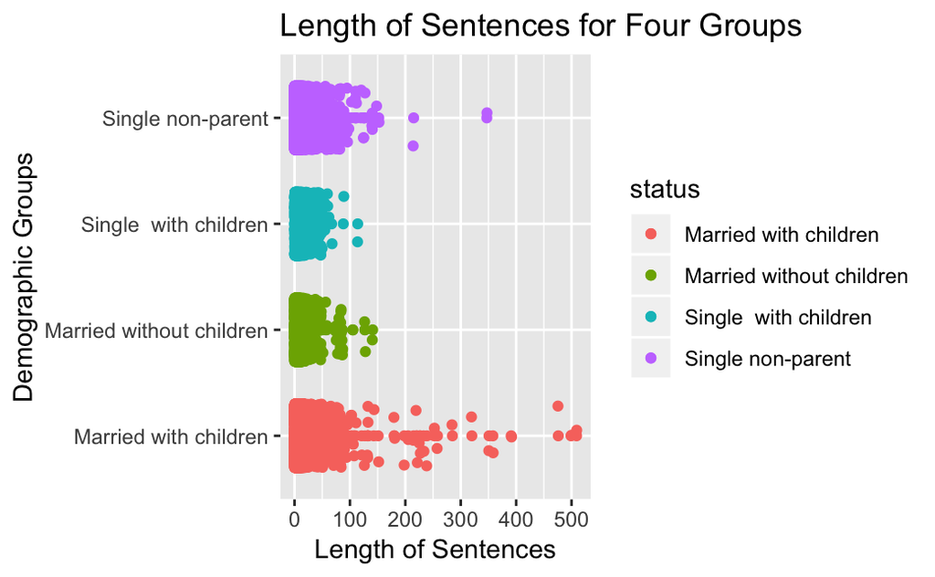

```r
ggplot(alldata, aes(count, status, color = status)) +
  geom_point() +
  geom_jitter(width = 1.0, height = 0.3) +
  ggtitle("Length of Sentences for Four Groups") +
  labs(x = "Length of Sentences", y = "Demographic Groups")
```

From this plot, we observe that married with children group wrote more words while descripting their happiness.

## Word Frequency for different group.

We are going to examine the frequencies of words for each group and generate a word cloud for each demographic group.

## Wordcloud for Single with children.

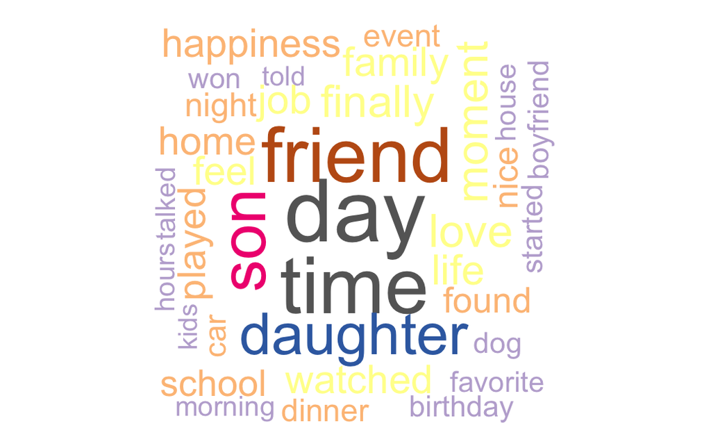

```r
#wordcloud for single with children.
docs.sp <- Corpus(VectorSource(hm_data.sp$text))
dtm.sp <- TermDocumentMatrix(docs.sp)
m.sp <- as.matrix(dtm.sp)
v.sp <- sort(rowSums(m.sp),decreasing=TRUE)
d.sp <- data.frame(word = names(v.sp),freq=v.sp)
set.seed(123)
wordcloud(words = d.sp$word, freq = d.sp$freq,
          min.freq = 1,
          max.words=40,
          random.order=FALSE,
          rot.per=0.35,
          use.r.layout = T,
          colors=brewer.pal(8, "Accent"))
```

## Wordcloud for Married with children

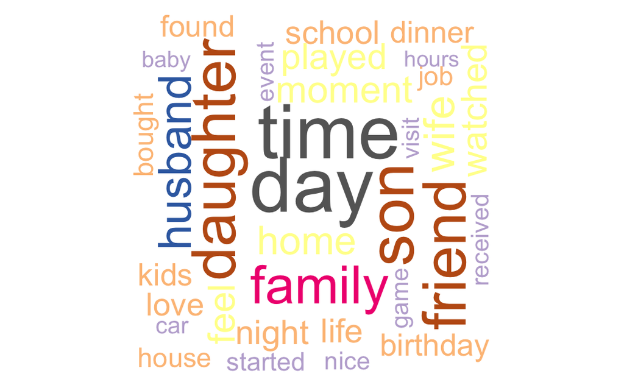

```r
#wordcloud for Married with children
docs.mp <- Corpus(VectorSource(hm_data.mp$text))
dtm.mp <- TermDocumentMatrix(docs.mp)
m.mp <- as.matrix(dtm.mp)
v.mp <- sort(rowSums(m.mp),decreasing=TRUE)
d.mp <- data.frame(word = names(v.mp),freq=v.mp)
set.seed(123)
wordcloud(words = d.mp$word, freq = d.mp$freq, min.freq = 1,
          max.words=40, random.order=FALSE, rot.per=0.35,
          colors=brewer.pal(8, "Accent"))
```

The top three most frequent appearance words are “day”, “time” and “friends” for single with children, while “day”, “time” and “son” for married people with children. “Friend” is the fifth order for married parents. This indicates that friends may be more important for singles than married ones.

## Top words for Reference groups.

To make things more accurate, we can also have a look at the reference groups.

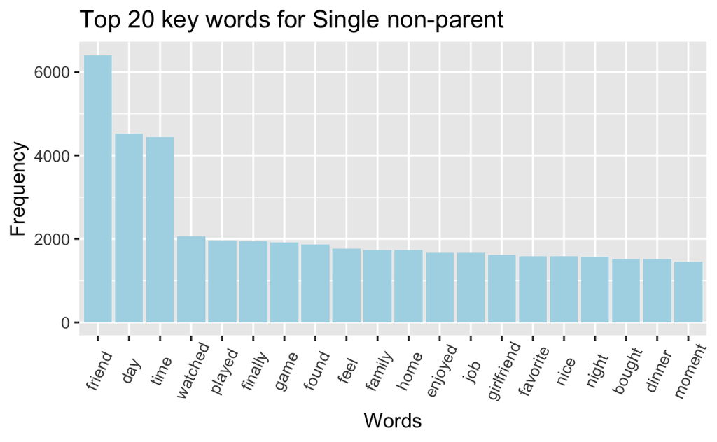

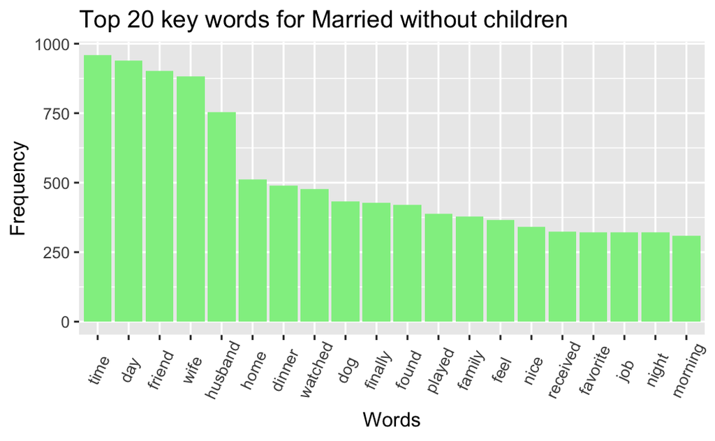

The top three most frequent words are the same for both groups– “day”, “time” and “friends”. Besides the obvious finding that non-parents would not have the term “son” or “daughter” on their lists, the words “family”, “husband”, and “wife” did not make it to the top three. For people who don’t have children, even if they are married, they seems to put more emphasize on friends instead of families.

# Sentiment Analysis

We will measure the sentiments of these happy statments.

The “tidytext” package provides several different lexicons that are dictionary of words with an sentiment assignment. Bing lexicon assigns words to positive and negative categories. AFINN lexicon assign each word with a score from -5 to 5 where higher score means more positive sentiment. We will examine the results using both lexicons.

First, we will use the Bing lexicon.

```r
bing <- function(df){
  tokens <- data_frame(df$text) %>% unnest_tokens(word, df$text)

  sentiment <- tokens %>%
  inner_join(get_sentiments("bing")) %>% # pull out the sentiment words
  count(sentiment) %>%   # count the number of positive and negative words
  spread(sentiment, n, fill = 0) %>%
  mutate(sentiment = positive/negative)

  return(sentiment)
}
bing.sp <- bing(hm_data.sp)$sentiment
```

```r
bing.mp <- bing(hm_data.mp)$sentiment
```

```r
bing.s <- bing(hm_data.s)$sentiment
```

```r
bing.m <- bing(hm_data.m)$sentiment
```

```r
bing.vec <- data.frame(bing = c(bing.sp, bing.mp,bing.s,bing.m))
```

Secondly, we will use the Afinn lexicon.

```r
afinn <- function(df){
tokens <- data_frame(df$text) %>% unnest_tokens(word, df$text)

sentiment <- tokens %>%
  inner_join(get_sentiments("afinn"))   # pull out the sentiment words and asign score

  return(sentiment)
}
afinn.sp <- mean(afinn(hm_data.sp)$score)
afinn.mp <-mean(afinn(hm_data.mp)$score)
afinn.s <-mean(afinn(hm_data.s)$score)
afinn.m <-mean(afinn(hm_data.m)$score)
afinn.vec <- data.frame(afinn = c(afinn.sp, afinn.mp,afinn.s,afinn.m))
```

```r
demo.vec <- c("Single with children", "Married with children", "Single without children", "Married without children")
both <- cbind(demo.vec,  bing.vec, afinn.vec)
colnames(both) <- c('Demographic_Groups', 'bing', 'afinn')
both
```

| Demographic_Groups | bing | afinn |
| --- | --- | --- |
| Single with children | 2.712033 | 1.424318 |
| Married with children | 2.722047 | 1.370004 |
| Single without children | 2.539738 | 1.342369 |
| Married without children | 2.643900 | 1.409176 |

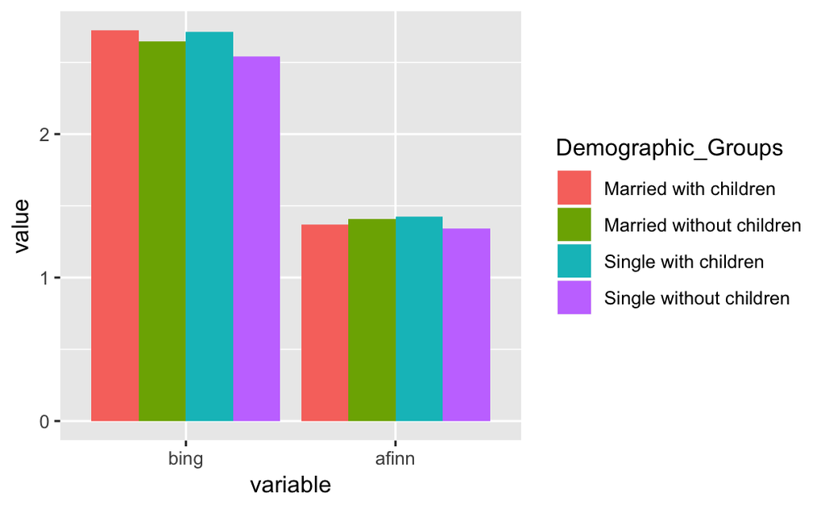

```r
melt.sentiments <- melt(both, id.vars = "Demographic_Groups")
ggplot(melt.sentiments, aes(variable, value)) +
  geom_bar(aes(fill = Demographic_Groups), position = "dodge", stat = "identity")
```

The sentiment score of bing lexicon is the amount of positive words divided by negative words. The results show that married with children have a slightly higher score than single with children. Parents generally shows more positive sentiments than non-parents.

The sentiment score of afinn lexicon is the mean of scores in each group. Interestingly, The results show that single parents have the highest score and single non-parents have the lowest score.

Comparing the two methods, there is not a significant difference between these demographic groups.

# Topic Modeling

We will extract topics with fitting a LDA model. We tried setting the numbers of topics as three to six. It turns out that setting three topics number make the most sense. The beta matrix tells us the probabilities of each word being generated from each topic.

We see that the word “accepted”" is generated from the topic 1 with a probability of 3.040925e-03. We visualized the top ten most frequent words in each topics. According to those words, we manually tag each topic as “Job”, “Family”,and “Friend”.

```r
# the beta matrix
topics <- tidy(lda, matrix = "beta")
head(topics,6)
```

| topic | term | beta |
| --- | --- | --- |
| 1 | accepted | 3.040925e-03 |
| 2 | accepted | 5.078872e-07 |
| 3 | accepted | 4.950885e-07 |
| 1 | afford | 7.633418e-04 |
| 2 | afford | 5.586760e-06 |
| 3 | afford | 4.950885e-07 |

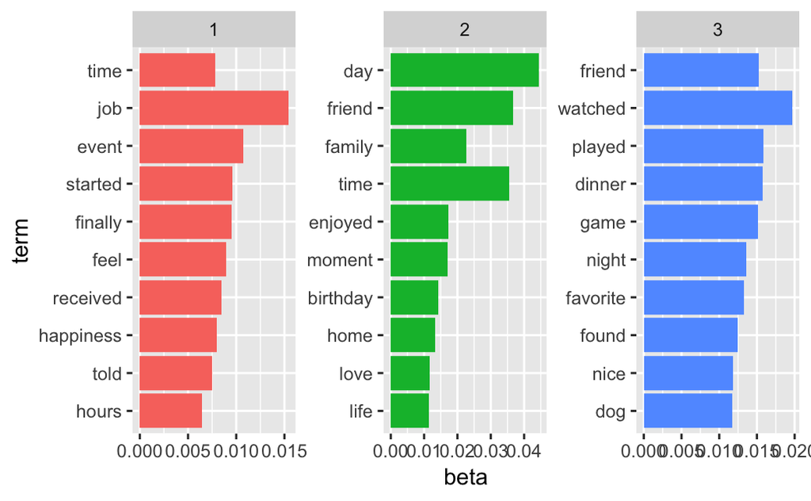

```r
#Find the top ten words in each topic.
top.words <- topics %>%
  group_by(topic) %>%
  top_n(10, beta) %>%
  ungroup() %>%
  arrange(topic, -beta)
top.words %>%
  mutate(term = reorder(term, beta)) %>%
  ggplot(aes(term, beta, fill = factor(topic))) +
  geom_col(show.legend = FALSE) +
  facet_wrap(~ topic, scales = "free") +
  coord_flip()
```

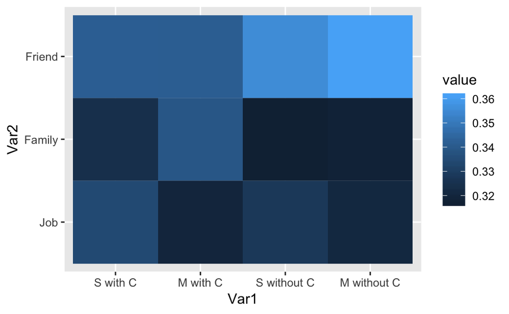

```r
topic.status<-tbl_df(combine.data.corpus)%>%
              select(status, Job:Friend)%>%
              group_by(status)%>%
              summarise_all(funs(mean))
topic.status=as.data.frame(topic.status)
rownames(topic.status)<-topic.status$status
as.mat <- as.matrix(topic.status[,-1])
rownames(as.mat) <- c('S with C','M with C','S without C','M without C')
melted_topic <- melt(as.mat)
ggplot(data = melted_topic, aes(x=Var1, y=Var2, fill=value)) +
  geom_tile()
```

We use a heat map to visualized which topic is mentioned more frequently for each demographic group. From the heat map, “friend” is a topic that are mentioned the most for all four groups. Married people with children find more happiness in families than other groups.

# Conclusion

There aren’t significant differences between single parents and other groups.

Considering the frequency of word，‘friend’ is more important for single parents than married parents. Family related words appear less for people who are married but don’t have children.

Among the three topics “job”, “family” and “friend”, “friend” is mentioned the most for all four groups. Married people with children talk more about families than other groups.